# Web Traffic Data Exploration, with Linear Regression Analysis

## Part 3: Running Linear Regression with sklearn

Following on from the summary of findings, the Scenario 2 dataframe (all_and_new_users_only) with the segments All Users and New Users will be used for Linear Regression models.

The Users column will be used as a predictor (X) for Sessions and Page Views as columns (y) in two separate Linear Regression Models. This is so predictions can be more easily made, based off users.

For each model:

- A test size of 40% of the 130 data points can be split for the test set (x_test and y_test)
- The remaining 60% would be used to train the model
- Please note in the real world the more data the better! this sample size may seem incredibly small
- The training set is then be **fit** to the Linear Regression model

Please note:

- lm_1 refers to the model fit with Users (X) and Sessions (y)
- lm_2 refers to the model fit with Users (X) and Page Views (y)

```python
import pandas as pd
from sklearn.model_selection import train_test_split
from sklearn.linear_model import LinearRegression

web_traffic_df = pd.read_csv('../assets/GA_web_traffic_data_12_08_20.csv')
web_traffic_df_copy = web_traffic_df.copy()
```

```
from sklearn.model_selection import train_test_split
from sklearn.linear_model import LinearRegression

all_and_new_users_only = web_traffic_df_copy[(web_traffic_df_copy['Segment']=='All Users')
                                             | (web_traffic_df_copy['Segment']=='New Users')]
all_and_new_users_only.drop(['Month of Year', 'Date Range', 'Segment'], axis=1, inplace=True)

users_X = all_and_new_users_only[['Users']]
sessions_y = all_and_new_users_only[['Sessions']]
page_views_y = all_and_new_users_only[['Page Views']]

lm_1 = LinearRegression()
lm_1_X_train, lm_1_X_test, lm_1_y_train, lm_1_y_test = train_test_split(users_X, sessions_y, test_size=0.4,
                                                                        random_state=101)
lm_1.fit(lm_1_X_train, lm_1_y_train)
```

```python
all_and_new_users_only = web_traffic_df_copy[(web_traffic_df_copy['Segment']=='All Users')
                                             | (web_traffic_df_copy['Segment']=='New Users')].copy()
all_and_new_users_only.drop(['Month of Year', 'Date Range', 'Segment'], axis=1, inplace=True)

users_X = all_and_new_users_only[['Users']]
sessions_y = all_and_new_users_only[['Sessions']]
page_views_y = all_and_new_users_only[['Page Views']]

lm_1 = LinearRegression()
lm_1_X_train, lm_1_X_test, lm_1_y_train, lm_1_y_test = train_test_split(users_X, sessions_y, test_size=0.4,
                                                                        random_state=101)
lm_1.fit(lm_1_X_train, lm_1_y_train)
```

```
LinearRegression(copy_X=True, fit_intercept=True, n_jobs=None, normalize=False)
```

```
lm_2 = LinearRegression()
lm_2_X_train, lm_2_X_test, lm_2_y_train, lm_2_y_test = train_test_split(users_X, page_views_y, test_size=0.4, random_state=101)
lm_2.fit(lm_2_X_train, lm_2_y_train)
```

```python
lm_2 = LinearRegression()
lm_2_X_train, lm_2_X_test, lm_2_y_train, lm_2_y_test = train_test_split(users_X, page_views_y, test_size=0.4, random_state=101)
lm_2.fit(lm_2_X_train, lm_2_y_train)
```

```
LinearRegression(copy_X=True, fit_intercept=True, n_jobs=None, normalize=False)
```

```python
lm_1_X_test.head(1)
```

|  | Users |
| --- | --- |
| 24 | 56011 |

Coefficient values can be derived from the models and presented in pandas dataframes:

```
coeff_lm_1 = pd.DataFrame(lm_1.coef_[0],users_X.columns, columns=['Linear Model 1 Coefficient: Users vs Sessions'])
coeff_lm_2 = pd.DataFrame(lm_2.coef_[0],users_X.columns, columns=['Linear Model 2 Coefficient: Users vs Page Views'])
print(coeff_lm_1, "\n")
print(coeff_lm_2)
```

```python
coeff_lm_1 = pd.DataFrame(lm_1.coef_[0],users_X.columns, columns=['Linear Model 1 Coefficient: Users vs Sessions'])
coeff_lm_2 = pd.DataFrame(lm_2.coef_[0],users_X.columns, columns=['Linear Model 2 Coefficient: Users vs Page Views'])
print(coeff_lm_1, "\n")
print(coeff_lm_2)
```

```
       Linear Model 1 Coefficient: Users vs Sessions
Users                                       1.192965

       Linear Model 2 Coefficient: Users vs Page Views
Users                                         3.781198
```

## Validating the Linear Regression models

Validating the models is important so we can understand their reliability in predicting results. Based on the models, it is posible to predict some values for y, by passing in test values for x:

```python
# Get predictions for model predicting Sessions (lm_1)

lm_1_y_pred = lm_1.predict(lm_1_X_test)

# Get predictions for model predicting Page Views (lm_2)

lm_2_y_pred = lm_2.predict(lm_2_X_test)
```

```
# Get predictions for model predicting Sessions (lm_1)

lm_1_y_pred = lm_1.predict(lm_1_X_test)

# Get predictions for model predicting Page Views (lm_2)

lm_2_y_pred = lm_2.predict(lm_2_X_test)
```

At this point it is posible to compare residuals for test values for y (y_test) against predicted values for y (y_pred), by exploring the following:

- Homoscedasticity
- Autocorrelation using the Durbin-Watson
- Regression Evalusation Metrics

I've found that [statisticssolutions](https://www.statisticssolutions.com/assumptions-of-linear-regression/) provides some straightforward explanations for these and this has helped me further explain concepts and findings.

## Homoscedasticity

For each model, a scatter plot and residual histogram can help provide an indicator of whether residuals are plotted equally accross the regression line

[output not shown]

```
Users vs Sessions Homoscedasticity Report (lm_1)
```

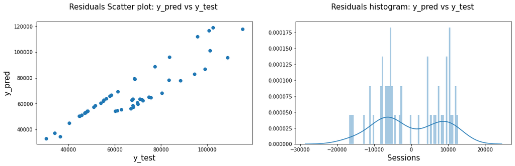

```python
import matplotlib.pyplot as plt
import seaborn as sns
%matplotlib inline

def get_homoscedasticity_report(y_test, y_pred, title, metric_name):
    print(title)
    plt.figure(figsize=(17, 4.5))

    # set up subplot for scatter plot
    ax1 = plt.subplot(121)
    ax1.scatter(y_test,y_pred)
    ax1.set_title('Residuals: y_pred vs y_test')
    ax1.set_xlabel('y_test', fontsize=15)
    ax1.set_ylabel('y_pred', fontsize=15)
    ax1.set_title('Residuals Scatter plot: y_pred vs y_test \n', fontsize=15)

    # set up subplot for residual histogram
    ax2 = plt.subplot(122)
    sns.distplot((y_test-y_pred),bins=70, ax=ax2)
    ax2.set_title('Residuals histogram: y_pred vs y_test \n', fontsize=15)
    ax2.set_xlabel(metric_name, fontsize=15)


get_homoscedasticity_report(lm_1_y_test, lm_1_y_pred, "Users vs Sessions Homoscedasticity Report (lm_1)", "Sessions")
```

```
get_homoscedasticity_report(lm_2_y_test, lm_2_y_pred,
                            "Users vs Page Views Homoscedasticity Report (lm_2)")
```

```
Users vs Page Views Homoscedasticity Report (lm_2)
```

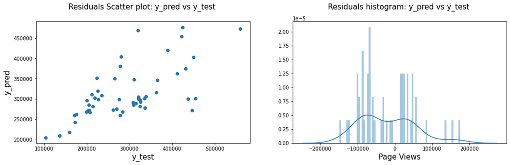

```python
get_homoscedasticity_report(lm_2_y_test, lm_2_y_pred, "Users vs Page Views Homoscedasticity Report (lm_2)", "Page Views")
```

### Homoscedasticity findings

Scatter plots

- A positive correlation between y_test and and y_pred is a lot more evident for Sessions (lm_1) than Page Views (lm_2)
- However this alone doesn't provide an indication of homoscedacity, particularly due to the lack of data points.

Residual histogram

- Histograms show that residuals for Sessions (lm_1) and Page Views (lm_2) do not necessarily conform to a normal distribution required for homoscedasticity.
- This warrants further investigation

## Futher Investigation with Histograms

Homoscedasticity findings can be investigated further by creating histograms for y_test and y_pred in reference to both models and comparing this with the normal distribution of data points which was found in the all_and_new_users_only dataframe.

```
def get_histogram_report(y_test, y_pred, title_tail_end, metric_name):
    print("Histogram Report: {}".format(title_tail_end))
    plt.figure(figsize=(17, 4.5))

    def set_up_histogram(subplot_no, data, title):
        title = 'Histogram: {} \n'.format(title)
        ax1 = plt.subplot(subplot_no)
        sns.distplot(data,bins=70, ax=ax1)
        ax1.set_title(title, fontsize=15)
        ax1.set_xlabel(metric_name, fontsize=15)

    set_up_histogram(131, y_test, "y_test")
    set_up_histogram(132, y_pred, "y_pred")
    set_up_histogram(133, all_and_new_users_only[[metric_name]], "all_and_new_users_only")

get_histogram_report(lm_1_y_test, lm_1_y_pred, "Sessions (lm_1)", "Sessions")
```

```
Histogram Report: Sessions (lm_1)
```

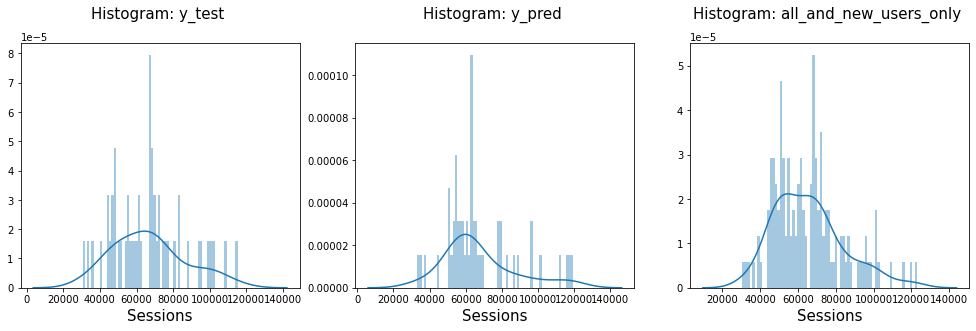

```python
def get_histogram_report(y_test, y_pred, title_tail_end, metric_name):
    print("Histogram Report: {}".format(title_tail_end))
    plt.figure(figsize=(17, 4.5))

    def set_up_histogram(subplot_no, data, title):
        title = 'Histogram: {} \n'.format(title)
        ax1 = plt.subplot(subplot_no)
        sns.distplot(data,bins=70, ax=ax1)
        ax1.set_title(title, fontsize=15)
        ax1.set_xlabel(metric_name, fontsize=15)

    set_up_histogram(131, y_test, "y_test")
    set_up_histogram(132, y_pred, "y_pred")
    set_up_histogram(133, all_and_new_users_only[[metric_name]], "all_and_new_users_only")

get_histogram_report(lm_1_y_test, lm_1_y_pred, "Sessions (lm_1)", "Sessions")
```

```
get_histogram_report(lm_2_y_test, lm_2_y_pred,
                     "Page Views Histogram Report (lm_2)", "Page Views")
```

```
Histogram Report: Page Views Histogram Report (lm_2)
```

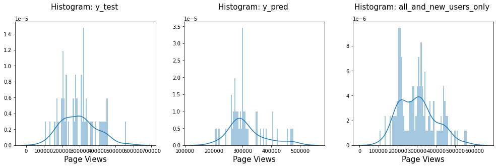

```python
get_histogram_report(lm_2_y_test, lm_2_y_pred, "Page Views Histogram Report (lm_2)", "Page Views")
```

## Autocorrelation

Running the Durbin-Watson test on the y_test and y_pred residuals can provide an indication of whether the linear relationship presented earlier is auto-correlated. Absence of this autocorrelation is a requirement for the linear regression model.

[Connor Johnson's code](http://connor-johnson.com/2014/02/18/linear-regression-with-python/) for running the Durbin-Watson test based on the statsmodel python library for linear regression, has been adapted so that the test can be run based on residuals from the sklearn version used herein:

- First of all residuals are derived for y_test and y_pred in a numpy array.
- The ravel function removes excessive squared brackets ([ ]) which need to be removed for the Durbin Watson function below.
- Please refer to online resources for further explanations on Durbin-Watson and numpy

```
import numpy as np

residuals = np.array(y_test-y_pred).ravel()

def get_durbin_watson(residuals):
    squared_residuals = np.square(residuals)
    sum_of_squared_residuals = np.sum(squared_residuals)
    DW = np.sum( np.diff(residuals )**2.0 ) / sum_of_squared_residuals
    return round(DW, 5)

print("Durbin-Watson result:", get_durbin_watson(residuals))
```

```python
import numpy as np

def get_durbin_watson_report(y_test, y_pred, title_tail_end):
    residuals = np.array(y_test-y_pred).ravel()
    squared_residuals = np.square(residuals)
    sum_of_squared_residuals = np.sum(squared_residuals)
    DW = np.sum( np.diff(residuals )**2.0 ) / sum_of_squared_residuals
    rounded_result = round(DW, 5)
    print("Durbin-Watson Report: Users vs {}".format(title_tail_end))
    print("Result: {}".format(rounded_result))

get_durbin_watson_report(lm_1_y_test, lm_1_y_pred, "Sessions (lm_1)")
```

```
Durbin-Watson Report: Users vs Sessions (lm_1)
Result: 1.713
```

```
get_durbin_watson_report(lm_2_y_test, lm_2_y_pred, "Page Views (lm_2)")
```

```python
get_durbin_watson_report(lm_2_y_test, lm_2_y_pred, "Page Views (lm_2)")
```

```
Durbin-Watson Report: Users vs Page Views (lm_2)
Result: 1.60637
```

### Durbin-Watson test findings

- The Durbin Watson test values are in the mid-range of 1.5 and 2.5, indicating no auto-correlation of the data.
- However, a limitation of this test is that it only analyses linear autocorrelation between neighbouring residual data points in the array. Selection of data points is not random.

## Regression Evaluation Metrics

Further to validating the linear regression model, there are metrics that can be imported from sklearn to evaluate the error associated with the model. These metrics reflect **loss** in the model and it can be adjusted to help minimise this and become more accurate.

```
from sklearn import metrics

def get_regression_evaluation_metrics_report(y_test, y_pred, title_tail_end):
    print("Regression Evaludation Metrics Report: {}\n".format(title_tail_end))
    mean_absolute_error = metrics.mean_absolute_error(y_test, y_pred)
    mean_squared_error = metrics.mean_squared_error(y_test, y_pred)
    root_mean_squared_error = np.sqrt(mean_squared_error)
    print('Mean Average Error (MAE):', mean_absolute_error)
    print('Mean Squared Error (MSE):', mean_squared_error)
    print('Root Mean Squared Error (RMSE):', root_mean_squared_error)

get_regression_evaluation_metrics_report(lm_1_y_test, lm_1_y_pred,
                                         "Sessions (lm_1)")
```

```python
from sklearn import metrics

def get_regression_evaluation_metrics_report(y_test, y_pred, title_tail_end):
    print("Regression Evaludation Metrics Report: {}\n".format(title_tail_end))
    mean_absolute_error = metrics.mean_absolute_error(y_test, y_pred)
    mean_squared_error = metrics.mean_squared_error(y_test, y_pred)
    root_mean_squared_error = np.sqrt(mean_squared_error)
    print('Mean Average Error (MAE):', mean_absolute_error)
    print('Mean Squared Error (MSE):', mean_squared_error)
    print('Root Mean Squared Error (RMSE):', root_mean_squared_error)

get_regression_evaluation_metrics_report(lm_1_y_test, lm_1_y_pred, "Sessions (lm_1)")
```

```
Regression Evaludation Metrics Report: Sessions (lm_1)

Mean Average Error (MAE): 7929.524883143552
Mean Squared Error (MSE): 75617956.61733888
Root Mean Squared Error (RMSE): 8695.85859000357
```

```
get_regression_evaluation_metrics_report(lm_2_y_test, lm_2_y_pred,
                                         "Page Views (lm_2)")
```

```python
get_regression_evaluation_metrics_report(lm_2_y_test, lm_2_y_pred, "Page Views (lm_2)")
```

```
Regression Evaludation Metrics Report: Page Views (lm_2)

Mean Average Error (MAE): 63947.6999485556
Mean Squared Error (MSE): 5667168307.555669
Root Mean Squared Error (RMSE): 75280.59715195987
```

### Evaluation metric findings

Metrics have been assessed with reference to 'An Introduction to Statistical Learning with applications for R' (James *et al.* 2015) and also numpy documentation.

#### Mean Average Error

- This represents a weighted average of all output errors, where zero represents the best outcome and the result shows a high value.

#### Mean Squared Error

- This metric provides an indication of the extent to which the predicted observation (y_pred) is close to the true observation (y_test).
- The mean squared value is very high for both models, particularly for lm_2, inferring that the difference between y_pred and y_test may differ substantially for some observations. A judgement can be made that the quality of fit is poor for both models.
- Thus in real-word terms, relying on these models for making predictions would not be recommended. This further emphasises the case for further data points for the model.

### Conclusions on Linear Regression Model findings

As the saying goes 'there's always room for improvement' and it goes without saying for the linear regression models presented herein. In hierarchial terms, foremost, it would be ideal to obtain more data points for the data set; whether that be adding further historical years or even further dimensions like 'device' to the Google analytics report. However, it's important to be aware that further segmentation of the data can lead to skew effects as was found for the Returning Users segment which was excluded from the models.

At a second tier, once the data has been split into training and testing data sets, it may be advisable to use histograms to check whether data still conforms to a normal distribution. This can help provide an indication of whether enough data points have been sampled in the first place. Moving on from establishing that the data still retains a normal distribution, it should then be posible to evaluate for further tests with more confidence in the model.

### Contents of Web Traffic Dashboard

The next section explores presenting web traffic data in a dashboard with insights and interactivity and this is split into sections. **Screenshots** are also provided below:

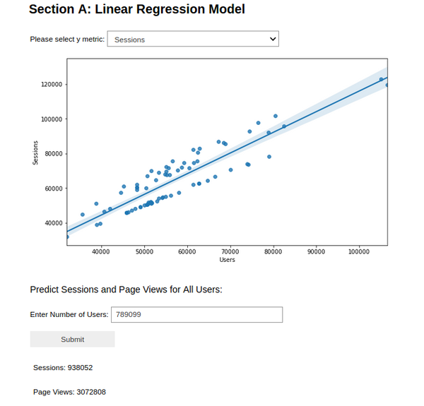

```python
from PIL import Image               # to load images
from IPython.display import display # to display images

basewidth = 600
pil_img = Image.open('../assets/dashboard_section_a.png')
wpercent = (basewidth/float(pil_img.size[0]))
hsize = int((float(pil_img.size[1])*float(wpercent)))
pil_img = pil_img.resize((basewidth,hsize), Image.ANTIALIAS)

display(pil_img)
```

- Shows Graphical representation for Linear Model based on training data using Seaborn.
- Predictor box provided so the number of Users can be entered to predict Sessions and Page Views.

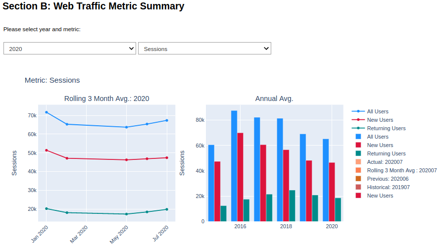

```python
pil_img = Image.open('../assets/dashboard_section_b_p1.png')

display(pil_img)
```

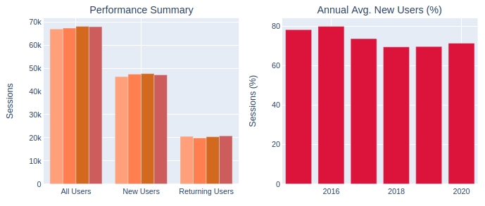

```python
pil_img = Image.open('../assets/dashboard_section_b_p2.png')

display(pil_img)
```

- Shows a dashboard to provide an overview on web metrics, built using plotly which offers interactive elements for graphs beyond dropdown widgets

## Accessing an interactive version of the dashboard

Here's the [jupyter notebook](https://github.com/Kremzeeq/ga_linear_regression_project/blob/master/jupyter_notebooks/GA_Linear_Regression_Analysis_P4-Dashboarding.ipynb) with source code for reproducing the dashboard.

This has taken inspiration from having previously produced web traffic dashboards in excel in a former life :)

Running all the cells shows the widgets as shown in screenshots above.

It's possible to access the notebook online, on Kaggle, however, this proved to be more complicated than one would like!!

### Steps for Accessing the Dashboard on Kaggle

1. Click this link: https://www.kaggle.com/kremzeeq/ga-linear-regression-analysis-dashboarding/edit
2. Click the blue Copy and Edit button
3. You have a Kaggle account, you can login and upload the GA_web_traffic_data_12_08_20.csv file.
4. Next, you should be able to click 'Run All' for the notebook with the dashboard and interact with notebook widgets.

Thanks for making it this far :)

### Finally, if you like this resource, please give a star to the [GitHub project](https://github.com/Kremzeeq/ga_linear_regression_project)!

```python
%%html
<style type="text/css">
div.jp-InputArea {
    display:none;
}
div.input {
    display:none;
}
</style>
```